# Rough Work

Hannes

2023-04-05

# 1 Data

Remove constant from dataset (no need for manual intercept).

After renames we have the variables

- `dvote` - the outcome variable, the Democratic party candidate’s share of the vote in the given state and year
- `year` - specifies the year of the election
- `state` - specifies the state of the corresponding outcome variable
- `evotes` - specifies the number of electors for a given state

Additionally we have the nationwide variables

- `dvote_poll` - the nationwide Democratic party candidate’s share of the vote in the September poll
- `dapprove_inc` - the nationwide presidential approval in the July poll (negative values for Republic presidents and positive values for Democratic presidents)
- `dapprove_presinc` - same as `dapprove_inc` but equals 0 if the current president is not running for a re-election
- `gnp_growth_inc` - the statewide GNP growth in the second quarter (positive values if the incumbent president is a Democrat and negative if the incumbent president is a Republican)

Furthermore we have the state wide variables

- `dvote_last` - the Democratic party candidate’s share of the last election given state and year (as a deviation from corresponding national vote)
- `dvote_last2` - the Democratic party candidate’s share two elections ago given state and year (as a deviation from corresponding national vote)
- `home_state` - the home state of the presidential candidate (+1 if the corresponding state is the home state of the Democratic candidate and -1 if the corresponding state is the home state of the Republican candidate)
- `home_state_vice` - the home state of the vice-presidential candidate (+1 if the corresponding state is the home state of the Democratic vice candidate and -1 if the corresponding state is the home state of the Republican vice candidate)
- `dmajor_leg` - the democratic majority in the state legislature (positive values if the Democrats had a majority compared to the Republicans and negative values if the Republicans had a majority compared to the Democrats)
- `econ_growth_inc` - the state economic growth in the past year (positive values if the incumbent president is a Democrat and negative if the incumbent president is a Republican)
- `state_ideology` - a measure for the state ideology (same value in every year) (positive values if ideology is more Democratic and negative values if ideology is more Republic)
- `ideology_comp` - ideological compatibility of a given state with the candidates (president and vice president)
- `cath_1960` - proportion of Catholics in 1960 compared to U.S. average and 0 in any other year (1960 had a Catholic presidential candidate)

Lastly we have the regional variables

- `south` - south indicator
- `south_1964` - south indicator in 1964
- `deep_south_1964` - deep south indicator in 1964
- `new_england_1964` - New England indicator in 1964
- `new_england_1972` - New England indicator in 1972
- `west_1976` - west indicator in 1976

The year 1964 was special because the Democratic candidate was able to completely dominate the elections, also in the south but with an exception of the deep south states. The other regional variables (`south`, `new_england_1972`, `west_1976`) are there to adjust for known and expected outliers (very unusual results in certain states and years) instead of removing them from the data.

We will treat year, state as well as all the regional variables as factor variables. All the remaining variables will be treated as numerical in our model.

# 2 Linear Model

Fit a first model excluding the inc and presinc variables and region.

Search for grouping in the data. Grouping in year or in region?

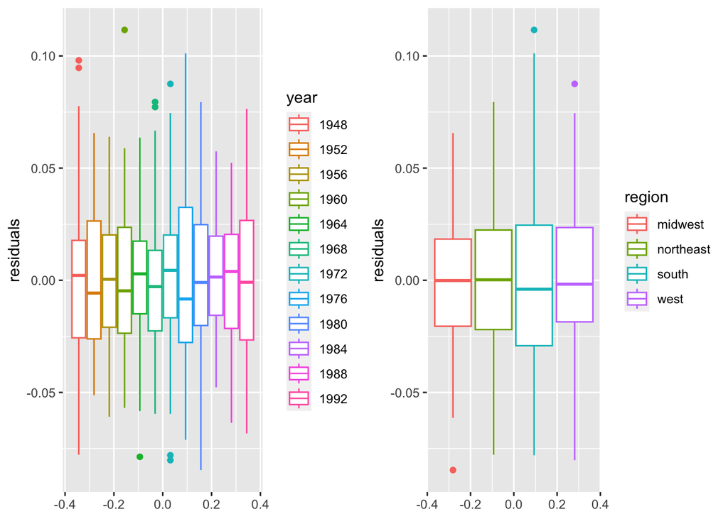

Two level grouping in year and region?

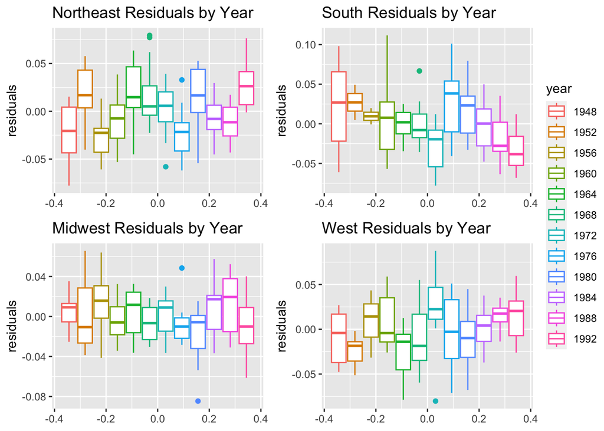

We find grouping of region inside the years, hence move to fixed effect models. We would like to allow for dependence between states in the same region in the same year.

Check if residuals are better now

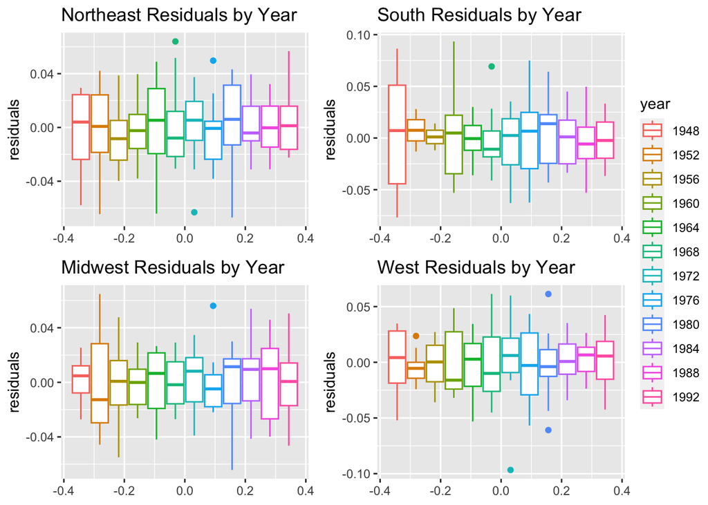

Much better now.

Can we reduce part of the random structure? Check if we can reduce random structure (1|year/region) = (1|year:region) + (1|year) to (1|year:region) + year (take away random effect on year only, since also the first residual plot of fixed model suggests that there is no grouping in year, only in year:region)

## 2.1 Questions

- Why first exclude region from model? Because region is already in the state variable and we only include it later to detect grouping and add use it for mixed model?
- What to do with observations with NA values?
- How to interpret the ideology variables?
- Nation wide variables lin dep to state?
- How would we discard region. Do we ever add region to the model without year? Since its makes design singular since dependent to state. Or not add state?